# EDA and predicting survival of patients with Heart Failure

## The Data

```r
library(ggplot2)
library(cowplot) # for arranging multiple plots
library(tidyverse) # tibbles
```

```r
# import the data and change some of the column names
df = read.csv("../S1Data.csv")

colnames(df)[1] = "Time"
colnames(df)[2] = "Death_Event" # if the patient deceased during the follow up period. 0 = survived, 1 = died
colnames(df)[6] = "High_Blood_Pressure"
colnames(df)[9] = "Ejection_Fraction"
colnames(df)[12] = "Platelets"
colnames(df)[13] = "CPK_Level"
```

Get a glimpse of the dataset.

```r
str(df)
```

```
## 'data.frame':    299 obs. of  13 variables:
##  $ Time               : int  97 180 31 87 113 10 250 27 87 87 ...
##  $ Death_Event        : int  0 0 1 0 0 1 0 1 0 0 ...
##  $ Gender             : int  0 1 1 1 1 1 1 1 1 1 ...
##  $ Smoking            : int  0 1 1 0 0 0 1 0 0 1 ...
##  $ Diabetes           : int  0 1 0 0 0 0 0 1 0 0 ...
##  $ High_Blood_Pressure: int  0 0 1 0 0 0 0 1 1 0 ...
##  $ Anaemia            : int  1 1 0 1 0 1 0 0 0 0 ...
##  $ Age                : num  43 73 70 65 64 75 70 94 75 80 ...
##  $ Ejection_Fraction  : int  50 30 20 25 60 15 40 38 45 25 ...
##  $ Sodium             : int  135 142 134 141 137 137 136 134 137 144 ...
##  $ Creatinine         : num  1.3 1.18 1.83 1.1 1 1.2 2.7 1.83 1.18 1.1 ...
##  $ Platelets          : num  237000 160000 263358 298000 242000 ...
##  $ CPK_Level          : int  358 231 582 305 1610 246 582 582 582 898 ...
```

The dataset contains a mix of variable types. There are 13 variables in total, with 299 observations. Binary features include Gender (0=female, 1=male), Smoking, Diabetes, High_Blood_Pressure, Anaemia, and the target variable Death_Event. Time, Age, Ejection_Fraction, Sodium, Creatinine, Platelets, and CPK_Level are numeric features.

Plots will be generated using ggplot. Before creating the plots, check for any missing values in the dataset.

```r
colSums(is.na(df))
```

```
##                Time         Death_Event              Gender             Smoking
##                   0                   0                   0                   0
##            Diabetes High_Blood_Pressure             Anaemia                 Age
##                   0                   0                   0                   0
##   Ejection_Fraction              Sodium          Creatinine           Platelets
##                   0                   0                   0                   0
##           CPK_Level
##                   0
```

## Stacked barplots of binary features

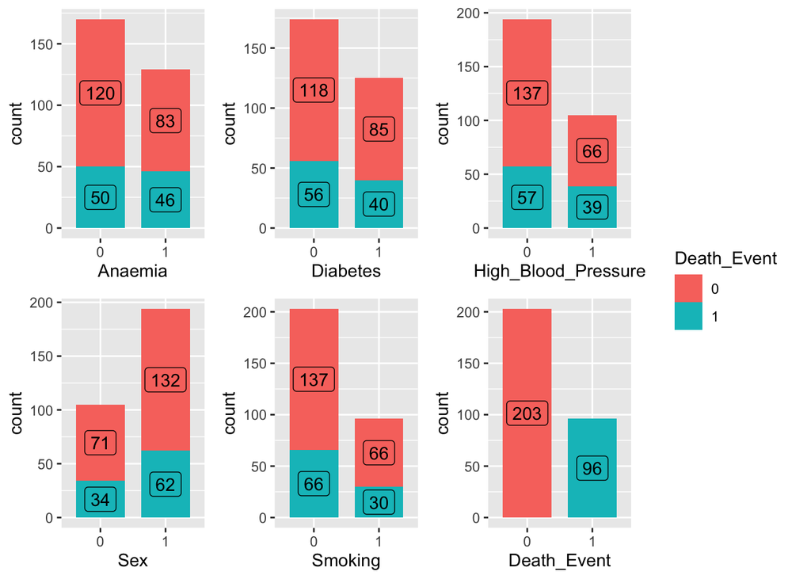

The above plots detail the counts of each class within each binary feature, which are further divided into patients who survived (pink) and patients who died (blue).

Non-anemics and anemics share close to equal proportions, as is the case for diabetics and non-diabetics. The remaining binary features show unbalance among each of their classes. For class 0 and 1 of each feature, patient survival (Death_Event=0) is the majority outcome.

The target variable (Death_Event) is not balanced. About 68% (203) of patients survived while around 32% (96) died.

```r
prop.table(table(df$Death_Event))
```

```
##
##         0         1
## 0.6789298 0.3210702
```

## Boxplots and density plots of numeric features

### Age

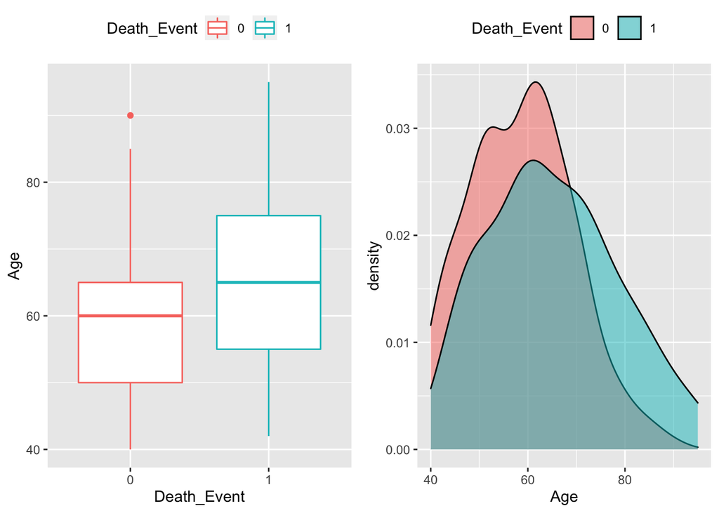

The median age of each group are similar, survivals hovered around 60 and deceased around 65. Deceased patients constitute 32% of the data but have a larger range in age than patients that survived.

### Creatinine Phosphokinase

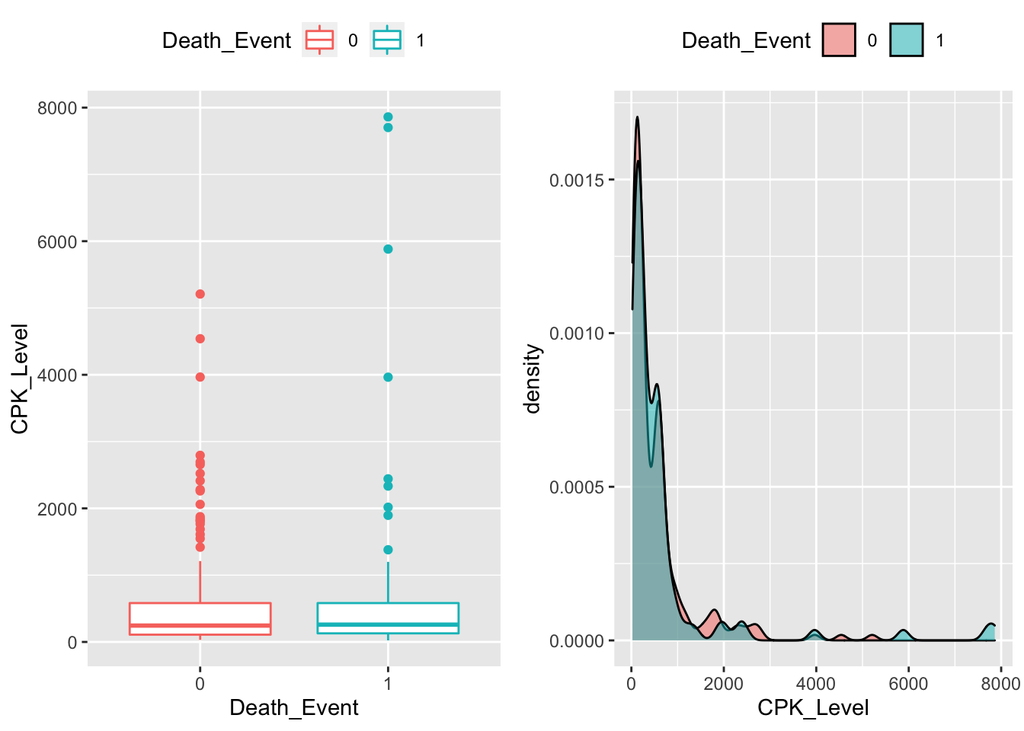

Both groups of patients had many positive outliers for creatinine phosphokinase levels, however deceased patients had observations of levels over 6000 mcg/L. The distributions are similar for both groups, with most of the data concentrated at creatinine phosphokinase levels under 1000 mcg/L.

### Ejection Fraction

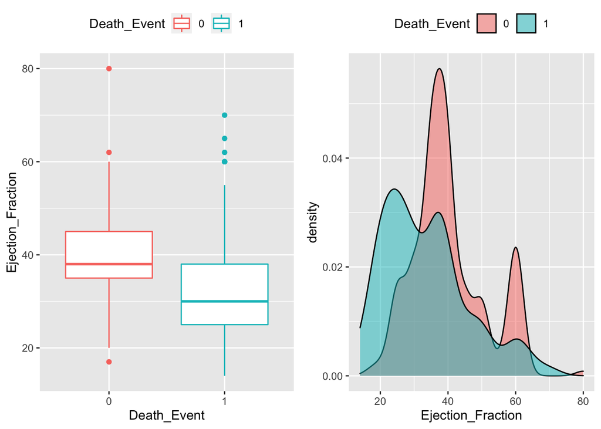

Both classes contain outliers and bimodal distributions. About 75% of individuals who died had ejection fraction percents lower than 40%.

### Platelets

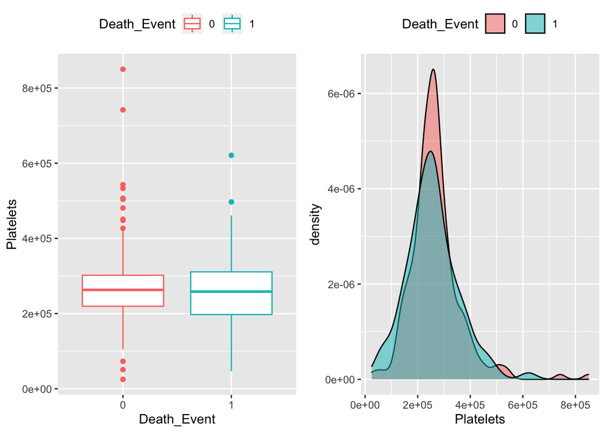

Count of platelets among both groups have similar distributions. There is slightly more variation in patients who died, but far more outliers in patients who survived. Both classes loosely follow a normal distribution.

### Serum Creatinine

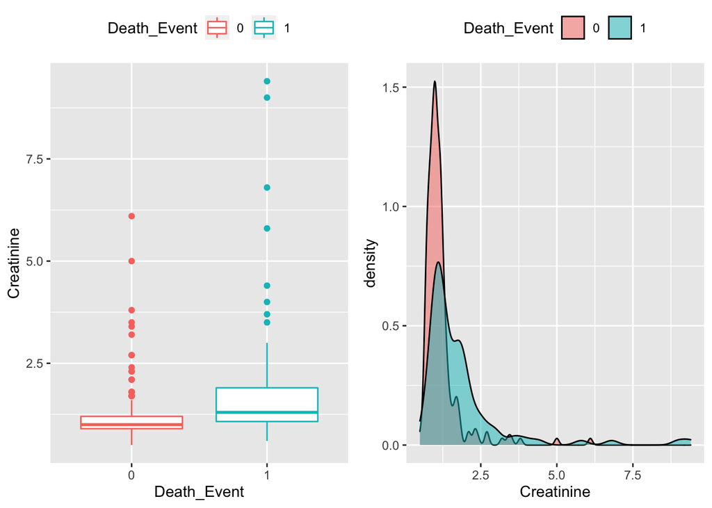

As was the case for the variables Platelets, CPK_Level, and Ejection_Fraction, outliers are observed for serum creatinine (Creatinine) levels in patients who survived/died. The density plot is skewed positively for both classes, with more variation in creatinine levels for patients who died.

### Sodium

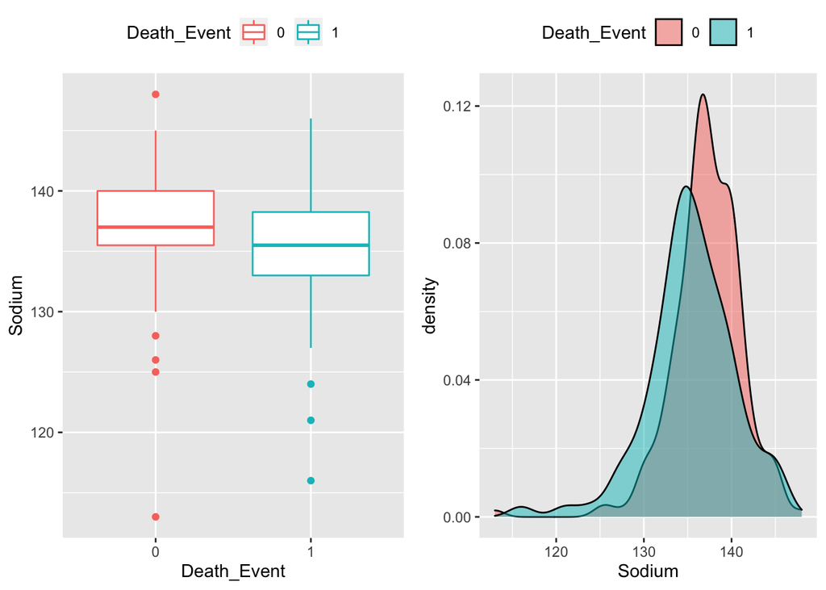

Sodium levels have a similar distribution among patients who survived and patients who died. Median values are similar among both groups, with outliers also observed in each group. Patients who died report slightly lower sodium levels than patients who survived.

### Time (days)

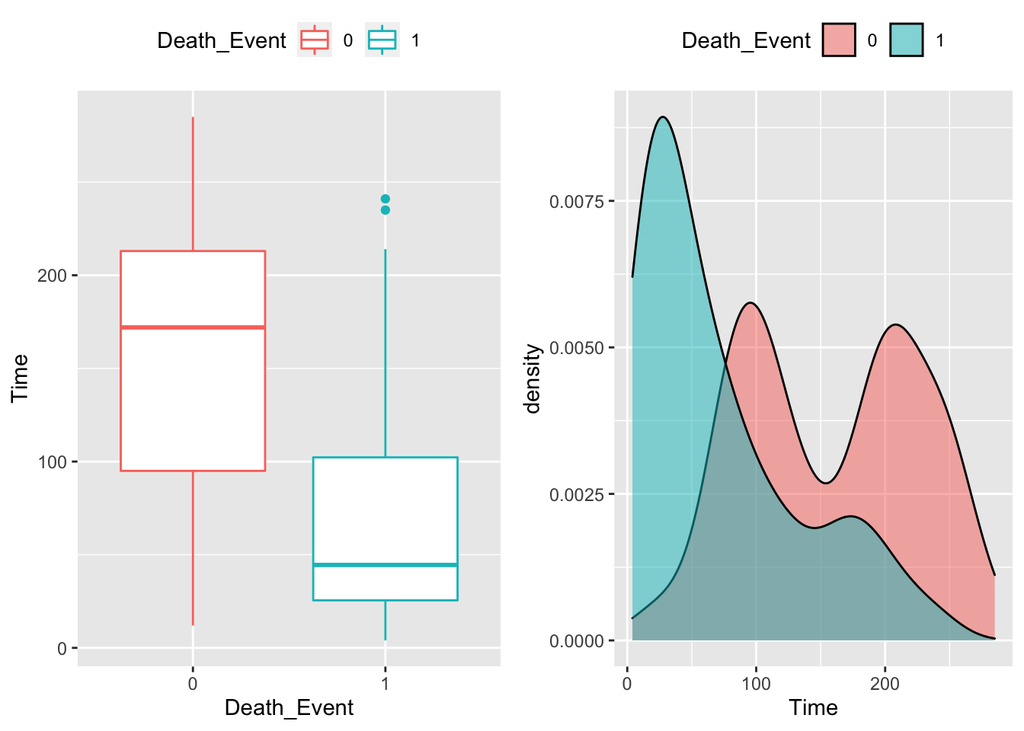

Patients who survived had more variation in their follow up time. About 75% of deceased patients had follow up times less than 100 days.

## How are the features in the dataset each related to Death_Event?

Feature selection can sometimes be used to improve model accuracy by filtering out the noise in the data. After initial model training and testing has finished, the models will be re-trained and tested using only the top features.

The Mann-Whitney U test can be used as a feature ranking method. It will compare the distribution of each feature for the values of Death_Event (survived and deceased) and return a p-value. Features having a p-value < 0.05 are strongly related to Death_Event, while features having a p-value > 0.05 are not related to Death_Event. More important features (higher rank) take on p-values close to 0.

```r
# p-val < 0.05 indicates the predictor variable strongly relates to death event
columnnames = colnames(df)
pvals = c()
for (i in columnnames) {
  if (i == "Death_Event") {
    next
  }
  temp = wilcox.test(df[[i]]~Death_Event, df)
  pvals[i] = temp$p.value
}
print(pvals)
```

```
##                Time              Gender             Smoking            Diabetes
##        6.852197e-21        9.412922e-01        8.281900e-01        9.739131e-01
## High_Blood_Pressure             Anaemia                 Age   Ejection_Fraction
##        1.710164e-01        2.529704e-01        1.667518e-04        7.368249e-07
##              Sodium          Creatinine           Platelets           CPK_Level
##        2.927557e-04        1.580998e-10        4.255585e-01        6.840400e-01
```

The variables most strongly associated with Death_Event (having a p-value < 0.05) are Time, Creatinine, Ejection_Fraction, Age, and Sodium. However, including the Time variable when training the models is not practical and doesn’t give any insight into predicting the survival of patients. Therefore, Time will be omitted from being used as a predictor in this analysis.

```r
# remove time from the df
df = subset(df, select=-Time)
```

## Splitting the data

In order to train and evaluate model performance the data needs to be split into training and testing data. Using initial_split from the rsample package will allow for the target features proportions to be conserved.

```r
library(rsample) # initial_split
```

```r
set.seed(100)
# split data into 70% training and 30% testing
df_split = initial_split(df, prop = 0.7, strata = Death_Event)
train = training(df_split)
test = testing(df_split)

# check that the proportions are the same in each set
prop.table(table(train$Death_Event))
```

```
##
##         0         1
## 0.6794258 0.3205742
```

```r
prop.table(table(test$Death_Event))
```

```
##
##         0         1
## 0.6777778 0.3222222
```

The training set contains 67.9% survivors and 32.1% deceased, while the testing set contains 67.7% survivors and 32.2% deceased.

The models will be trained and tuned using the caret package. Cross-validation will be performed on the training data to optimize selection of hyperparameters, with final validation done on the testing data.

```r
library(caret) # training the models
```

```r
set.seed(100)
trctrl = trainControl(method="cv", number=9, verboseIter=FALSE)
```

## Decision tree

```r
# build the decision tree
set.seed(100)
dt = train(Death_Event~., data=train, method="rpart",
           trControl=trctrl,
           tuneGrid=expand.grid(cp=c(0.001,0.01, 0.03, 0.3, 1)))
print(dt)
```

```
## CART
##
## 209 samples
##  11 predictor
##   2 classes: '0', '1'
##
## No pre-processing
## Resampling: Cross-Validated (9 fold)
## Summary of sample sizes: 185, 186, 186, 186, 187, 185, ...
## Resampling results across tuning parameters:
##
##   cp     Accuracy   Kappa
##   0.001  0.6554860  0.1509979
##   0.010  0.6556873  0.1344655
##   0.030  0.6893390  0.2529534
##   0.300  0.6796955  0.0000000
##   1.000  0.6796955  0.0000000
##
## Accuracy was used to select the optimal model using the largest value.
## The final value used for the model was cp = 0.03.
```

```
## # A tibble: 1 × 5
##      cp Accuracy Kappa AccuracySD KappaSD
##   <dbl>    <dbl> <dbl>      <dbl>   <dbl>
## 1  0.03    0.689 0.253     0.0911   0.254
```

The decision tree was able to classify the training data with 69% accuracy.

## Random forest

```r
# build the random forest model
set.seed(100)
rf = train(Death_Event~., data=train, method="ranger",
           trControl=trctrl,
           importance="permutation",
           tuneGrid=expand.grid(mtry=c(2,3,4,5),
                                min.node.size=c(5,10,20,40),
                                splitrule=c("gini",
                                            "extratrees")))
print(rf)
```

```
## Random Forest
##
## 209 samples
##  11 predictor
##   2 classes: '0', '1'
##
## No pre-processing
## Resampling: Cross-Validated (9 fold)
## Summary of sample sizes: 185, 186, 186, 186, 187, 185, ...
## Resampling results across tuning parameters:
##
##   mtry  min.node.size  splitrule   Accuracy   Kappa
##   2      5             gini        0.7082967  0.2548200
##   2      5             extratrees  0.6998792  0.1501977
##   2     10             gini        0.7129264  0.2753914
```

[output cut: 33 more lines]

```
## # A tibble: 1 × 7
##    mtry min.node.size splitrule Accuracy Kappa AccuracySD KappaSD
##   <dbl>         <dbl> <fct>        <dbl> <dbl>      <dbl>   <dbl>
## 1     5            40 gini         0.737 0.379     0.0587   0.137
```

The random forest model performed with 74% accuracy during training.

## Support vector machine

```r
# build the support vector machine model
set.seed(100)
svm = train(Death_Event~., data=train, method="svmLinear",
            verbose=FALSE, trControl=trctrl,
            preProcess = c("center", "scale"),
            tuneGrid=expand.grid(C=c(0.001,0.01,0.1,1,5,10)))
print(svm)
```

```
## Support Vector Machines with Linear Kernel
##
## 209 samples
##  11 predictor
##   2 classes: '0', '1'
##
## Pre-processing: centered (11), scaled (11)
## Resampling: Cross-Validated (9 fold)
## Summary of sample sizes: 185, 186, 186, 186, 187, 185, ...
## Resampling results across tuning parameters:
##
##   C      Accuracy   Kappa
##   1e-03  0.6796955  0.00000000
##   1e-02  0.6803360  0.02311305
##   1e-01  0.7091385  0.23946722
##   1e+00  0.7371176  0.34313496
##   5e+00  0.7371176  0.34313496
##   1e+01  0.7371176  0.34313496
##
## Accuracy was used to select the optimal model using the largest value.
## The final value used for the model was C = 1.
```

```
## # A tibble: 1 × 5
##       C Accuracy Kappa AccuracySD KappaSD
##   <dbl>    <dbl> <dbl>      <dbl>   <dbl>
## 1     1    0.737 0.343     0.0835   0.194
```

The SVM was also able to classify the target variable with 74% accuracy.

## Gradient boosting machine

```r
train_gbm = training(df_split)
test_gbm = testing(df_split)
train_gbm$Death_Event = ifelse(
  train_gbm$Death_Event==0,"Survived", "Deceased")
test_gbm$Death_Event = ifelse(
  test_gbm$Death_Event==0,"Survived", "Deceased")

set.seed(100)
# let the algorithm try out randomized params instead of tuning
# ourselves
gbm = train(Death_Event~.,
            data=train_gbm,
            method="gbm",
            verbose=FALSE,
            trControl=trctrl,
            tuneLength=30)
gbm
```

```
## Stochastic Gradient Boosting
##
## 209 samples
##  11 predictor
##   2 classes: 'Deceased', 'Survived'
##
## No pre-processing
## Resampling: Cross-Validated (9 fold)
## Summary of sample sizes: 187, 185, 185, 187, 186, 186, ...
## Resampling results across tuning parameters:
##
##   interaction.depth  n.trees  Accuracy   Kappa
##    1                   50     0.7409603  0.35939524
##    1                  100     0.7409603  0.36760253
##    1                  150     0.7222405  0.32228007
```

[output cut: 904 more lines]

```
## # A tibble: 1 × 8
##   shrinkage interaction.depth n.minobsinnode n.trees Accuracy Kappa AccuracySD
##       <dbl>             <int>          <dbl>   <dbl>    <dbl> <dbl>      <dbl>
## 1       0.1                 1             10      50    0.741 0.359     0.0981
## # … with 1 more variable: KappaSD <dbl>
```

Gradient boosting also reported an accuracy of 74% on the training data.

Performance will be gauged by calculating the accuracy, recall and precision achieved on testing and training sets. Avoiding models that overfit and have low recall will be accomplished by tuning hyperparameters and reducing the amount of noise in the data via feature selection.

Since the target variable is unbalanced, looking at the recall of each model will indicate how well they were able to predict the minority class. Low recall could indicate a bias for the majority class, meaning the model is unable to distinguish patients who died from patients who survived.

### DT results

```r
# dt
pred_dt = predict(dt, test)
cm_dt = confusionMatrix(pred_dt, test$Death_Event, positive="1")
cm_dt
```

```
## Confusion Matrix and Statistics
##
##           Reference
## Prediction  0  1
##          0 53  9
##          1  8 20
##
##                Accuracy : 0.8111
##                  95% CI : (0.7149, 0.8859)
##     No Information Rate : 0.6778
##     P-Value [Acc > NIR] : 0.003498
##
##                   Kappa : 0.5636
##
##  Mcnemar's Test P-Value : 1.000000
##
##             Sensitivity : 0.6897
##             Specificity : 0.8689
##          Pos Pred Value : 0.7143
##          Neg Pred Value : 0.8548
##              Prevalence : 0.3222
##          Detection Rate : 0.2222
##    Detection Prevalence : 0.3111
##       Balanced Accuracy : 0.7793
##
##        'Positive' Class : 1
##
```

```r
# print out additional information on the model results
cm_dt$byClass
```

```
##          Sensitivity          Specificity       Pos Pred Value
##            0.6896552            0.8688525            0.7142857
##       Neg Pred Value            Precision               Recall
##            0.8548387            0.7142857            0.6896552
##                   F1           Prevalence       Detection Rate
##            0.7017544            0.3222222            0.2222222
## Detection Prevalence    Balanced Accuracy
##            0.3111111            0.7792538
```

The decision tree was able to achieve an accuracy of 81%, precision of 71%, and recall of 69% on the testing data. During training, the model reported an accuracy of 69%.

### RF results

```r
# rf
pred_rf = predict(rf, test)
cm_rf = confusionMatrix(pred_rf, test$Death_Event, positive="1")
cm_rf
```

```
## Confusion Matrix and Statistics
##
##           Reference
## Prediction  0  1
##          0 58 13
##          1  3 16
##
##                Accuracy : 0.8222
##                  95% CI : (0.7274, 0.8948)
##     No Information Rate : 0.6778
##     P-Value [Acc > NIR] : 0.001599
##
##                   Kappa : 0.5525
##
##  Mcnemar's Test P-Value : 0.024449
##
##             Sensitivity : 0.5517
##             Specificity : 0.9508
##          Pos Pred Value : 0.8421
##          Neg Pred Value : 0.8169
##              Prevalence : 0.3222
##          Detection Rate : 0.1778
##    Detection Prevalence : 0.2111
##       Balanced Accuracy : 0.7513
##
##        'Positive' Class : 1
##
```

```r
cm_rf$byClass
```

```
##          Sensitivity          Specificity       Pos Pred Value
##            0.5517241            0.9508197            0.8421053
##       Neg Pred Value            Precision               Recall
##            0.8169014            0.8421053            0.5517241
##                   F1           Prevalence       Detection Rate
##            0.6666667            0.3222222            0.1777778
## Detection Prevalence    Balanced Accuracy
##            0.2111111            0.7512719
```

The random forest model has an accuracy of 82%, precision of 84%, and recall of 55% on the testing set. The model performed with 74% accuracy during training.

### SVM results

```r
# svm
pred_svm = predict(svm, test)
cm_svm = confusionMatrix(pred_svm, test$Death_Event,
                         positive="1")
cm_svm
```

```
## Confusion Matrix and Statistics
##
##           Reference
## Prediction  0  1
##          0 56 20
##          1  5  9
##
##                Accuracy : 0.7222
##                  95% CI : (0.6178, 0.8115)
##     No Information Rate : 0.6778
##     P-Value [Acc > NIR] : 0.21648
##
##                   Kappa : 0.2642
##
##  Mcnemar's Test P-Value : 0.00511
##
##             Sensitivity : 0.3103
##             Specificity : 0.9180
##          Pos Pred Value : 0.6429
##          Neg Pred Value : 0.7368
##              Prevalence : 0.3222
##          Detection Rate : 0.1000
##    Detection Prevalence : 0.1556
##       Balanced Accuracy : 0.6142
##
##        'Positive' Class : 1
##
```

```r
cm_svm$byClass
```

```
##          Sensitivity          Specificity       Pos Pred Value
##            0.3103448            0.9180328            0.6428571
##       Neg Pred Value            Precision               Recall
##            0.7368421            0.6428571            0.3103448
##                   F1           Prevalence       Detection Rate
##            0.4186047            0.3222222            0.1000000
## Detection Prevalence    Balanced Accuracy
##            0.1555556            0.6141888
```

The support vector machine has performed the worst so far, with an accuracy of 72%, precision of 64%, and recall of 31%. During training accuracy was at 74%, meaning the model overfit on the testing data.

### GBM results

```r
# gbm
pred_gbm = predict(gbm, test_gbm)
cm_gbm = confusionMatrix(pred_gbm, factor(test_gbm$Death_Event))
cm_gbm
```

```
## Confusion Matrix and Statistics
##
##           Reference
## Prediction Deceased Survived
##   Deceased       15        4
##   Survived       14       57
##
##                Accuracy : 0.8
##                  95% CI : (0.7025, 0.8769)
##     No Information Rate : 0.6778
##     P-Value [Acc > NIR] : 0.00716
##
##                   Kappa : 0.4966
##
##  Mcnemar's Test P-Value : 0.03389
##
##             Sensitivity : 0.5172
##             Specificity : 0.9344
##          Pos Pred Value : 0.7895
##          Neg Pred Value : 0.8028
##              Prevalence : 0.3222
##          Detection Rate : 0.1667
##    Detection Prevalence : 0.2111
##       Balanced Accuracy : 0.7258
##
##        'Positive' Class : Deceased
##
```

```r
cm_gbm$byClass
```

```
##          Sensitivity          Specificity       Pos Pred Value
##            0.5172414            0.9344262            0.7894737
##       Neg Pred Value            Precision               Recall
##            0.8028169            0.7894737            0.5172414
##                   F1           Prevalence       Detection Rate
##            0.6250000            0.3222222            0.1666667
## Detection Prevalence    Balanced Accuracy
##            0.2111111            0.7258338
```

The gradient boosted model performed well, with an accuracy of 80%, precision of 79%, and recall of 52%. During training, the model performed with 74% accuracy.

## Feature Ranking

Feature ranking will be used in an attempt to get a performance increase from the previous models. The same training process will be followed, with slight variation in the hyperparameters.

How did each of the models rank the various features in the dataset?

### Decision tree feature ranking

```r
library(rpart.plot)
```

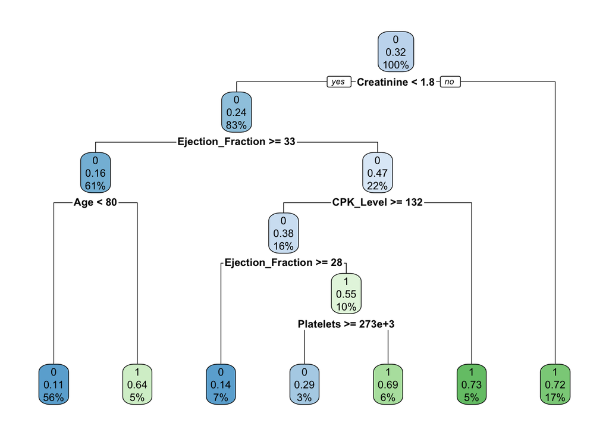

```r
rpart.plot(dt$finalModel)
```

```r
varImp(dt, scale=FALSE)
```

```
## rpart variable importance
##
##                     Overall
## Ejection_Fraction    20.490
## Age                  17.890
## Creatinine           17.286
## Sodium               13.650
## High_Blood_Pressure   5.454
## Platelets             4.884
## CPK_Level             3.044
## Diabetes              1.875
## Smoking               0.000
## Anaemia               0.000
## Gender                0.000
```

Plotting the decision tree helps visualize how features are ranked, with the most important features appearing at the root of the tree. The DT model lists Creatinine, Ejection_Fraction, Age, and CPK_Level as the top 4 features. However, when passing varImp() the DT, the function generates different results: Ejection_Fraction, Age, Creatinine, and Sodium are listed as the top 4 features. This could be due to differences in how caret and rpart calculate feature importance.

### Gradient boosted machine feature ranking

```r
library(gbm)
varImp(gbm, scale=FALSE)
```

```
## gbm variable importance
##
##                     Overall
## Creatinine          20.0924
## Ejection_Fraction   17.4402
## Age                 16.8153
## Sodium               9.3767
## Platelets            4.7652
## High_Blood_Pressure  3.1099
## CPK_Level            0.6001
## Diabetes             0.0000
## Gender               0.0000
## Anaemia              0.0000
## Smoking              0.0000
```

Recall that the results from the Mann-Whitney U test listed Creatinine, Ejection_Fraction, Age and Sodium as the most important features (disregarding Time) in order of importance. Interesting enough, the GB model listed Creatinine, Ejection_Fraction, Age and Sodium in the same order as the ranking in the Mann-Whitney U test.

### Random forest feature ranking

```r
varImp(rf, scale=FALSE)
```

```
## ranger variable importance
##
##                        Overall
## Creatinine           5.117e-02
## Ejection_Fraction    3.443e-02
## Age                  1.884e-02
## Sodium               9.341e-03
## Gender               9.756e-06
## Smoking             -2.333e-04
## Anaemia             -5.530e-04
## High_Blood_Pressure -9.950e-04
## CPK_Level           -1.603e-03
## Diabetes            -1.683e-03
## Platelets           -1.750e-03
```

```r
#importance(rf$finalModel) -> same results as above
```

The RF model also lists Creatinine, Ejection_Fraction, Age, and Sodium as the top 4 important features.

## Re-training the models using the top features

The models will be re-trained using only the top 4 features. The SVM will be trained with the most consistent top features, those being Creatinine, Ejection_Fraction, Age, and Sodium.

### DT

```r
# build the decision tree with the top 4 features
set.seed(100)
dt_best_feats = train(Death_Event~Creatinine+Ejection_Fraction+Age+Sodium, data=train, method="rpart",
           trControl=trctrl,
           tuneLength=10)
#print(dt_best_feats)
as_tibble(dt_best_feats$results[which.max(dt_best_feats$results[,2]),])
```

```
## # A tibble: 1 × 5
##      cp Accuracy Kappa AccuracySD KappaSD
##   <dbl>    <dbl> <dbl>      <dbl>   <dbl>
## 1 0.106    0.757 0.358     0.0568   0.185
```

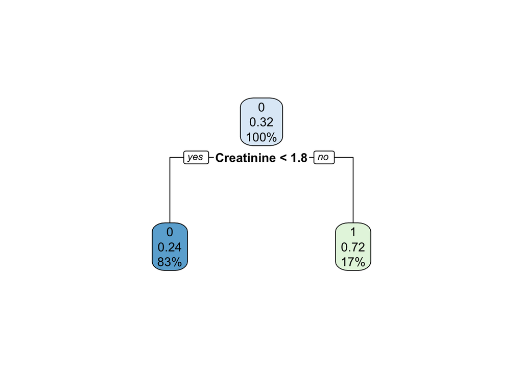

```r
# plot our model
rpart.plot(dt_best_feats$finalModel)
```

The DT has only one split. This may be too general in classifying observations, in which case another model will be built with smaller cp values tested.

```r
# see how the model does when tested against the testing data
pred_dt_bf = predict(dt_best_feats, test)
cm_dt_bf = confusionMatrix(pred_dt_bf, test$Death_Event, positive="1")
cm_dt_bf
```

```
## Confusion Matrix and Statistics
##
##           Reference
## Prediction  0  1
##          0 58 20
##          1  3  9
##
##                Accuracy : 0.7444
##                  95% CI : (0.6416, 0.8306)
##     No Information Rate : 0.6778
##     P-Value [Acc > NIR] : 0.1058161
##
##                   Kappa : 0.3086
##
##  Mcnemar's Test P-Value : 0.0008492
##
##             Sensitivity : 0.3103
##             Specificity : 0.9508
##          Pos Pred Value : 0.7500
##          Neg Pred Value : 0.7436
##              Prevalence : 0.3222
##          Detection Rate : 0.1000
##    Detection Prevalence : 0.1333
##       Balanced Accuracy : 0.6306
##
##        'Positive' Class : 1
##
```

```r
cm_dt_bf$byClass
```

```
##          Sensitivity          Specificity       Pos Pred Value
##            0.3103448            0.9508197            0.7500000
##       Neg Pred Value            Precision               Recall
##            0.7435897            0.7500000            0.3103448
##                   F1           Prevalence       Detection Rate
##            0.4390244            0.3222222            0.1000000
## Detection Prevalence    Balanced Accuracy
##            0.1333333            0.6305822
```

Accuracy (74%) and recall (31%) decreased compared to the original DT (81% and 69%, respectively). Precision increased slightly (71% to 75%). Better results may be obtained by selecting smaller cp values to test, as this allows for a deeper tree to be grown.

```r
# bad results from above, smaller cp value will allow for a deeper tree to be grown
set.seed(100)
t = train(Death_Event~Creatinine+Ejection_Fraction+Age+Sodium,
          data=train, method="rpart",
          trControl=trctrl,
          tuneGrid=expand.grid(cp=c(0.01,0.02,0.025,0.03,0.035)))
#print(t)
as_tibble(t$results[which.max(t$results[,2]),])
```

```
## # A tibble: 1 × 5
##      cp Accuracy Kappa AccuracySD KappaSD
##   <dbl>    <dbl> <dbl>      <dbl>   <dbl>
## 1  0.02    0.718 0.336     0.0526   0.148
```

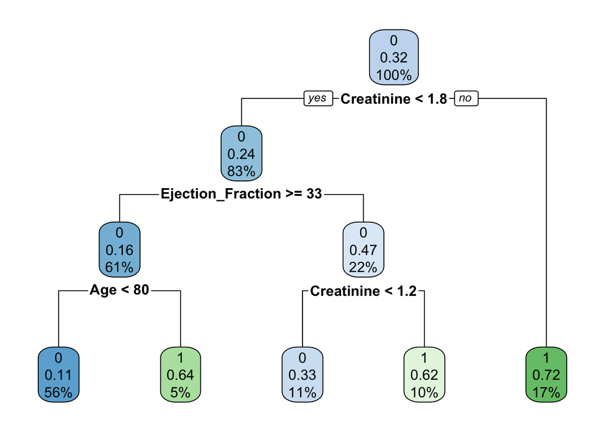

```r
rpart.plot(t$finalModel)
```

```r
# tree looks good, see how it performs on the test data
pred_t = predict(t, test)
cm_t = confusionMatrix(pred_t, test$Death_Event, positive="1")
cm_t
```

```
## Confusion Matrix and Statistics
##
##           Reference
## Prediction  0  1
##          0 55 11
##          1  6 18
##
##                Accuracy : 0.8111
##                  95% CI : (0.7149, 0.8859)
##     No Information Rate : 0.6778
##     P-Value [Acc > NIR] : 0.003498
##
##                   Kappa : 0.5471
##
##  Mcnemar's Test P-Value : 0.331975
##
##             Sensitivity : 0.6207
##             Specificity : 0.9016
##          Pos Pred Value : 0.7500
##          Neg Pred Value : 0.8333
##              Prevalence : 0.3222
##          Detection Rate : 0.2000
##    Detection Prevalence : 0.2667
##       Balanced Accuracy : 0.7612
##
##        'Positive' Class : 1
##
```

```r
cm_t$byClass
```

```
##          Sensitivity          Specificity       Pos Pred Value
##            0.6206897            0.9016393            0.7500000
##       Neg Pred Value            Precision               Recall
##            0.8333333            0.7500000            0.6206897
##                   F1           Prevalence       Detection Rate
##            0.6792453            0.3222222            0.2000000
## Detection Prevalence    Balanced Accuracy
##            0.2666667            0.7611645
```

Making the tree deeper increased the accuracy back to 81%. Recall worsened slightly (62%) as compared to the original model (69%), while precision improved (71% to 75%).

### RF

```r
# build the random forests model
set.seed(100)
# set node size smaller to get trees with larger depth
rf_best_feats = train(Death_Event~Creatinine+Ejection_Fraction+Age+Sodium, data=train, method="ranger",
           trControl=trctrl,
           tuneGrid=expand.grid(mtry=c(2,3,4),
                                min.node.size=c(20,30,40),
                                splitrule=c("gini",
                                            "extratrees")))
#print(rf_best_feats)
as_tibble(rf_best_feats$results[which.max(rf_best_feats$results[,4]),])
```

```
## # A tibble: 1 × 7
##    mtry min.node.size splitrule Accuracy Kappa AccuracySD KappaSD
##   <dbl>         <dbl> <fct>        <dbl> <dbl>      <dbl>   <dbl>
## 1     2            40 gini         0.732 0.371     0.0656   0.149
```

```r
pred_rf_bf = predict(rf_best_feats, test)
cm_rf_bf = confusionMatrix(pred_rf_bf, test$Death_Event, positive="1")
cm_rf_bf
```

```
## Confusion Matrix and Statistics
##
##           Reference
## Prediction  0  1
##          0 55 13
##          1  6 16
##
##                Accuracy : 0.7889
##                  95% CI : (0.6901, 0.8679)
##     No Information Rate : 0.6778
##     P-Value [Acc > NIR] : 0.01376
##
##                   Kappa : 0.484
##
##  Mcnemar's Test P-Value : 0.16867
##
##             Sensitivity : 0.5517
##             Specificity : 0.9016
##          Pos Pred Value : 0.7273
##          Neg Pred Value : 0.8088
##              Prevalence : 0.3222
##          Detection Rate : 0.1778
##    Detection Prevalence : 0.2444
##       Balanced Accuracy : 0.7267
##
##        'Positive' Class : 1
##
```

```r
cm_rf_bf$byClass
```

```
##          Sensitivity          Specificity       Pos Pred Value
##            0.5517241            0.9016393            0.7272727
##       Neg Pred Value            Precision               Recall
##            0.8088235            0.7272727            0.5517241
##                   F1           Prevalence       Detection Rate
##            0.6274510            0.3222222            0.1777778
## Detection Prevalence    Balanced Accuracy
##            0.2444444            0.7266817
```

The RF performed slightly worse than the original model, going from 82% accuracy to 79%. Recall remained the same (55%), while precision also decreased from 84% to 73%.

### SVM

```r
# SVM without noise
set.seed(100)
svm_best_feats = train(Death_Event~Creatinine+Ejection_Fraction+Age+Sodium, data=train, method="svmLinear",
            verbose=FALSE, trControl=trctrl,
            preProcess = c("center", "scale"),
            tuneGrid=expand.grid(C=c(0.001,0.01,0.1,1)))
#print(svm_best_feats)
as_tibble(svm_best_feats$results[which.max(svm_best_feats$results[,3]),])
```

```
## # A tibble: 1 × 5
##       C Accuracy Kappa AccuracySD KappaSD
##   <dbl>    <dbl> <dbl>      <dbl>   <dbl>
## 1     1    0.728 0.277     0.0501   0.160
```

```r
pred_svm_bf = predict(svm_best_feats, test)
cm_svm_bf = confusionMatrix(pred_svm_bf, test$Death_Event,
                         positive="1")
cm_svm_bf
```

```
## Confusion Matrix and Statistics
##
##           Reference
## Prediction  0  1
##          0 58 18
##          1  3 11
##
##                Accuracy : 0.7667
##                  95% CI : (0.6657, 0.8494)
##     No Information Rate : 0.6778
##     P-Value [Acc > NIR] : 0.04253
##
##                   Kappa : 0.3819
##
##  Mcnemar's Test P-Value : 0.00225
##
##             Sensitivity : 0.3793
##             Specificity : 0.9508
##          Pos Pred Value : 0.7857
##          Neg Pred Value : 0.7632
##              Prevalence : 0.3222
##          Detection Rate : 0.1222
##    Detection Prevalence : 0.1556
##       Balanced Accuracy : 0.6651
##
##        'Positive' Class : 1
##
```

```r
cm_svm_bf$byClass
```

```
##          Sensitivity          Specificity       Pos Pred Value
##            0.3793103            0.9508197            0.7857143
##       Neg Pred Value            Precision               Recall
##            0.7631579            0.7857143            0.3793103
##                   F1           Prevalence       Detection Rate
##            0.5116279            0.3222222            0.1222222
## Detection Prevalence    Balanced Accuracy
##            0.1555556            0.6650650
```

The SVM performed better in every respect. Accuracy increased to 77% from 72%, recall increased to 38% from 31%, and precision increased to 79% from 64%.

### GBM

```r
set.seed(100)
# let the algorithm try out randomized params instead of tuning
# ourselves
gbm_best_feats = train(Death_Event~Creatinine+Ejection_Fraction+Age+Sodium,
            data=train_gbm,
            method="gbm",
            verbose=FALSE,
            trControl=trctrl,
            tuneLength=10)
#gbm_best_feats
```

```
## # A tibble: 1 × 8
##   shrinkage interaction.depth n.minobsinnode n.trees Accuracy Kappa AccuracySD
##       <dbl>             <int>          <dbl>   <dbl>    <dbl> <dbl>      <dbl>
## 1       0.1                 2             10      50    0.736 0.357      0.105
## # … with 1 more variable: KappaSD <dbl>
```

```r
pred_gbm_bf = predict(gbm_best_feats, test_gbm)
cm_gbm_bf = confusionMatrix(pred_gbm_bf, factor(test_gbm$Death_Event))
cm_gbm_bf
```

```
## Confusion Matrix and Statistics
##
##           Reference
## Prediction Deceased Survived
##   Deceased       18        5
##   Survived       11       56
##
##                Accuracy : 0.8222
##                  95% CI : (0.7274, 0.8948)
##     No Information Rate : 0.6778
##     P-Value [Acc > NIR] : 0.001599
##
##                   Kappa : 0.5696
##
##  Mcnemar's Test P-Value : 0.211300
##
##             Sensitivity : 0.6207
##             Specificity : 0.9180
##          Pos Pred Value : 0.7826
##          Neg Pred Value : 0.8358
##              Prevalence : 0.3222
##          Detection Rate : 0.2000
##    Detection Prevalence : 0.2556
##       Balanced Accuracy : 0.7694
##
##        'Positive' Class : Deceased
##
```

```r
cm_gbm_bf$byClass
```

```
##          Sensitivity          Specificity       Pos Pred Value
##            0.6206897            0.9180328            0.7826087
##       Neg Pred Value            Precision               Recall
##            0.8358209            0.7826087            0.6206897
##                   F1           Prevalence       Detection Rate
##            0.6923077            0.3222222            0.2000000
## Detection Prevalence    Balanced Accuracy
##            0.2555556            0.7693612
```

The GBM model improved in accuracy (80% to 82%) and recall (52% to 62%), but had worse precision (79% to 78%).

## Model performance visualized

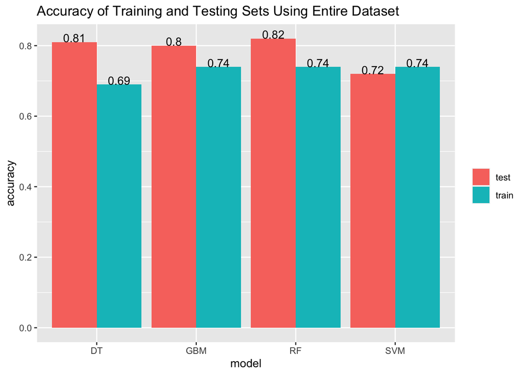

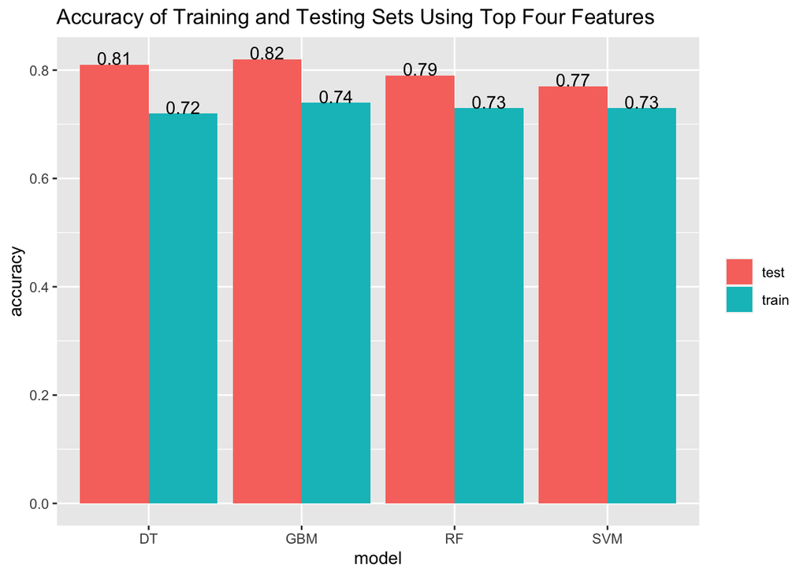

Focusing on both training and testing accuracy alone, feature selection was able to gain improvement for the decision tree, gradient boosted machine and support vector machine. Feature selection had most improvement on the support vector machine, while it caused a decline in accuracy for the random forest. None of the models that trained with the top 4 features overfit on the testing data.

## Results

Model performance results

|  | DT_initial | DT_improved | RF_initial | RF_improved | SVM_initial | SVM_improved | GBM_initial | GBM_improved |
| --- | --- | --- | --- | --- | --- | --- | --- | --- |
| training accuracy | 0.69 | 0.72 | 0.74 | 0.73 | 0.74 | 0.73 | 0.74 | 0.74 |
| testing accuracy | 0.81 | 0.81 | 0.82 | 0.79 | 0.72 | 0.77 | 0.80 | 0.82 |
| recall | 0.69 | 0.62 | 0.55 | 0.55 | 0.31 | 0.38 | 0.52 | 0.62 |
| precision | 0.71 | 0.75 | 0.84 | 0.73 | 0.64 | 0.79 | 0.79 | 0.78 |

The best performing models were the initial decision tree, the improved gradient boosted machine, and the initial random forest. These models had the highest testing accuracy and balance between precision and recall.

The worst performing models were both support vector machines, followed by the improved random forest.

## Conclusion

Feature selection helped gain performance increases for the SVM and GBM models. It also didn’t cause significantly worse results to be generated by the DT and RF models. The SVM saw additional benefits by avoiding overfitting on the testing set. Given these observations, it seems worthwhile to explore shrinking the feature space by removing redundant predictors when training classification models.

For this dataset, predicting a positive death event (achieving high recall) is of high interest due to the implications of real-world situations. Maintaining high precision is also of importance, and finding the balance between the two is a common problem for classifying unbalanced datasets. While reducing the feature space produced positive impact on the GBM and SVM models in this sense, plotting the precision-recall curve for each of the models could give more information on expected performance and aid in balancing precision and recall. This information can also help in optimizing model selection for a given dataset.

Overall, cross-validation and feature selection were able to create robust, well performing models. Sometimes additional hyperparameter tuning may be needed, as was the case when training the decision tree with the top features. Future applications using this dataset could involve exploring other classification models, or assessing the effect of incorporating additional top features during the training process.